# Introduction

## Clustering

Since we now have an idea of how the misogynistic comments are structured through topic modelling, we want test an UML algorithm to cluster the comments together to see if it can identify the misogynistic comments in other ways than by use of the predefined categorical values.

```python
# Dimensionality reduction of data to plot in clusters, scaling the topic matrix index.
embeddings = umap.UMAP(n_neighbors=15, metric='cosine').fit_transform(document_topic_matrix_ix)
```

```python
# Choosing amount of clusters based upon the amount of catagorical outcomes; misogynism and not misogynism.
clusterer = KMeans(n_clusters = 2)
# Fitting the data to the clustering
clusterer.fit(document_topic_matrix_ix)
```

```
KMeans(algorithm='auto', copy_x=True, init='k-means++', max_iter=300,
       n_clusters=2, n_init=10, n_jobs=None, precompute_distances='auto',
       random_state=None, tol=0.0001, verbose=0)
```

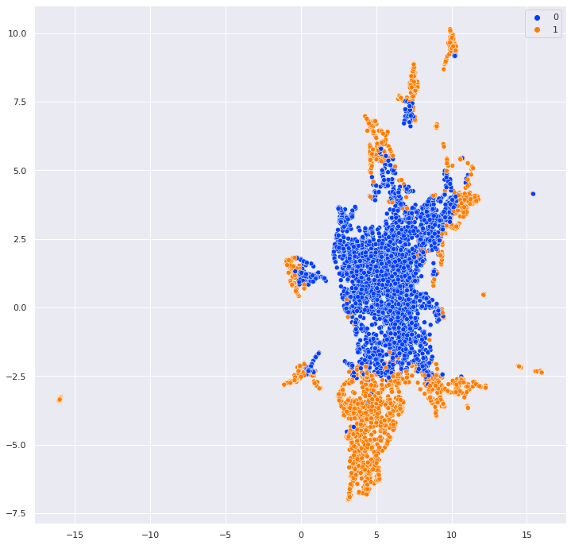

```python
# Plotting clusters, color based on UML clustering.
plt.rcParams.update({'font.size': 12})
plt.figure(figsize=(12,12))
g = sns.scatterplot(*embeddings.T,
                   hue=clusterer.labels_,
                    palette="bright",
                   legend='full')
```

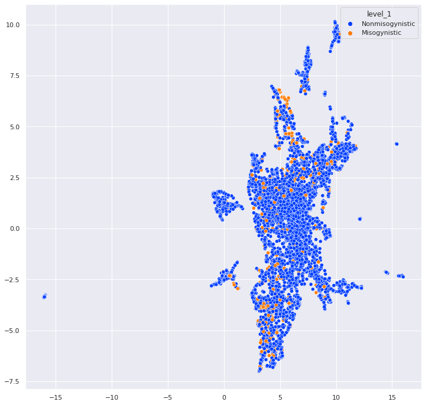

```python
# Plotting clusters, color based on UML clustering. Showing clustering coloring based on misogynistic labeled comments.
plt.rcParams.update({'font.size': 12})
plt.figure(figsize=(12,12))
g = sns.scatterplot(*embeddings.T,
                   hue=miso_data['level_1'],
                    palette="bright",
                   legend='full')
```

As seen in the above clusters, the UML models used were not particularly able to cluster up the misogynistic comments. You can see in the top cluster that it has a big central cluster with a surrounding cluster, but when we relabel the data in the scatterplot for the categorical comment tags, it becomes clear that the non misogynistic comments are widespread in the cluster and there's no intuitive reasoning for the clustering.

There can be several reasons why this happened, such as our data set being particularly small and the algorithm not really having enough misogynistic comments to identify. It can also be argued that misogyny has a very specific structure where its hard to identify because the definition of misogyny is subjective. I.e. a personal attack, will not be tagged as misogyny. The comment has to specifically be targeting women as a gender and not just target a specific woman, which could make it hard to differentiate.

# Supervised machine learning

By using supervised machine learning, we can create a model that predicts the probability of the comments of the dataset being labeled as misogynistic using the reddit comment data.

## Logistic regression

The reason we have chosen a regression model, is that we want to predict whether or not a specific comment from the data set is misogynistic or nonmisogynistic. Therefore, we are talking about a classification problem where the response variable is either true/false etc.

For test size, we chose 5% of the dataset, which indicate a rather small test size. Reason being that we want to train the model as much as possible because we want to use it on another dataset. Another argument is that the amount of misogynistic compared to nonmisogynistic is rather small, so we ought to find a test seed with enough misogynistic comments.

```python
# Labeling the "level_1" column with labelencoder to use it in the crosstab as our catagorical variable
Y_cat = miso_data['level_1']
labelencoder_y = LabelEncoder()
Y_cat = labelencoder_y.fit_transform(Y_cat)
```

```python
# Splitting the data to test and train sets, using 95% for training and 5% for testing.
X_train, X_test, Y_train, Y_test = train_test_split(X, Y_cat, test_size = 0.05, random_state = 2**32-1)
```

```python
# Running the logistical regression model as the default binary classification because we only have 2 catagorical variables.
model = LogisticRegression()
model = model.fit(X_train, Y_train)
```

```python
# Showing the R^2 score of the model, showing a prediction accuracy of ~91%
# Though, this is not very representative for the acutal accuracy because of the focus on misogynistic comments.
# Whereas this score is only representative of the overall accuracy.
model.score(X_test, Y_test)
```

```
0.9099378881987578
```

```python
# Displaying the probability predictions of the comments.
# The numerical probabilities is shown as probability for misogynism on the left and vice versa
# Though this is better shown in a crosstab.
model.predict_proba(X_test)[:10]
```

```
array([[0.05567812, 0.94432188],
       [0.07604822, 0.92395178],
       [0.04986013, 0.95013987],
       [0.04885254, 0.95114746],
       [0.03768229, 0.96231771],
       [0.5562568 , 0.4437432 ],
       [0.02919138, 0.97080862],
       [0.14260556, 0.85739444],
       [0.06071131, 0.93928869],
       [0.03710111, 0.96289889]])
```

```python
# Transforming the categorical variables back to the original labels 'Misogynistic' and 'Nonmisogynistic' for display in the crosstab.
true_cat = labelencoder_y.inverse_transform(Y_test)
predicted_cat = labelencoder_y.inverse_transform(model.predict(X_test))

# Convert the data back into a dataframe.
data_pred_true = pd.DataFrame({'predicted_cat': predicted_cat, 'true_cat': true_cat})
```

```python
# Displaying crosstab for predicted and actual categorical placement of comments:
pd.crosstab(data_pred_true.true_cat, data_pred_true.predicted_cat)
```

| predicted_cat true_cat | Misogynistic | Nonmisogynistic |
| --- | --- | --- |
| Misogynistic | 11 | 28 |
| Nonmisogynistic | 1 | 282 |

```python
# Showing a classification report for the predictions:
print(classification_report(true_cat,predicted_cat, labels=labelencoder_y.classes_))
```

```
                 precision    recall  f1-score   support

   Misogynistic       0.92      0.28      0.43        39
Nonmisogynistic       0.91      1.00      0.95       283

       accuracy                           0.91       322
      macro avg       0.91      0.64      0.69       322
   weighted avg       0.91      0.91      0.89       322
```

As shown above the r^2 score relatively high, 90%, but looking at the crosstab and the classification report we recognize a problem; the recall from the classification report is 0.28 which is the measure of how great our model is at identifying a true positive. In this case 0.28 in recall is not a great result if we will use this model on another dataset. Therefore, we will try to use another algorithm to test the data on.

## XGB model

XGB or Extreme Gradiant Boosting is a decision tree algorithm, which is efficient at handling sparse data. This should result in it being good in the case of our purpose of classifying on a binary categorical value as well as the data consisting of only around 10% of misogynistic comments. Whereas we will use the XGB classifier model for this purpose.

```python
# Same procedure as the logistical regression, but using XGB instead.
Y_xgb = miso_data['level_1']
labelencoder_y = LabelEncoder()
Y_xgb = labelencoder_y.fit_transform(Y_xgb)
```

```python
# Splitting the data using the assumptions as before
X_train_xgb, X_test_xgb, Y_train_xgb, Y_test_xgb = train_test_split(X, Y_xgb, test_size = 0.05, random_state = 2**32-1)
```

```python
# Running the XGB model with default settings
model_xgb = XGBClassifier()
model_xgb.fit(X_train_xgb,Y_train_xgb)
Y_pred_xgb = model_xgb.predict(X_test_xgb)
model_xgb.score(X_test_xgb, Y_test_xgb)
```

```
0.9347826086956522
```

This appears slightly more precise compared with the logistical regression that was at ~91%, therefore the XGB model is approximatly 2.5 percentages points better. But we still want to inspect it visually by using a cross tab and get a classification report

```python
true_explained_xgb = labelencoder_y.inverse_transform(Y_test_xgb)
predicted_explained_xgb = labelencoder_y.inverse_transform(model_xgb.predict(X_test_xgb))

# Convert the data back into a dataframe.
data_pred_true_xgb = pd.DataFrame({'predicted_explained_xgb': predicted_explained_xgb, 'true_explained_xgb': true_explained_xgb})

# Plot using a crosstab.
pd.crosstab(data_pred_true_xgb.true_explained_xgb, data_pred_true_xgb.predicted_explained_xgb)
```

| predicted_explained_xgb true_explained_xgb | Misogynistic | Nonmisogynistic |
| --- | --- | --- |
| Misogynistic | 22 | 17 |
| Nonmisogynistic | 4 | 279 |

```python
print(classification_report(true_explained_xgb,predicted_explained_xgb, labels=labelencoder_y.classes_))
```

```
                 precision    recall  f1-score   support

   Misogynistic       0.85      0.56      0.68        39
Nonmisogynistic       0.94      0.99      0.96       283

       accuracy                           0.93       322
      macro avg       0.89      0.77      0.82       322
   weighted avg       0.93      0.93      0.93       322
```

Contrary to the regular logistic regression model, the XGB classifier on default settings shows a more promising result, as the recall of identifying misogynistic comments has increased by 0.28 or 11 observations on the same split.

Given the above classification report and crosstab is representative as a sample size of a ‘real’ implication of the model, we are still only getting slightly above 50% of the misogynistic comments flagged, even with the XGB model.

Were these comments to be deemed inappropriate on SoMe platforms, we would prefer to have more true positives with respect to identifying misogynism rather than letting half of them pass through the algorithm.

Hyperparameter tuning the XGB model is deemed preferable to increase recall score on the misogynistic category

## Hyperparameter tuning of XGB

Hyperparameter tuning is effectively tweaking the settings of the, in our case, XGB model as to make it better in our specific case of prediction. This may or may not increase the model’s efficiency, precision and accuracy dependent on which settings are tuned. Tuning the model calls for testing by trial and error, and in the end, a model that scores better after tuning may be prone to overfitting.

```python
# Tuning for max depth, estimators, gamma and scale pos weight
# Max depth was selected based on a typical value of 3-10, though our chosen value of 10 may cause overfitting.
# n_estimators was selected based on www.analyticsvidhya.com, who states amount of trees (n_estimators) should be an amount the computing processor can handle for consistency of the model.
# Gamma was selected as 1 to make the model more conservative, reducing the threshold for minimum loss reduction for making a split.
# Scale_pos_weight was tuned because of the imbalance in the class scales.
  # Stated on a XGBoost guidepage, we found that a preferable value would be the positive instances divided by the negative instances.
xgb_tuned=xgb.XGBClassifier(max_depth=10, n_estimators=600, gamma=1, scale_pos_weight=280/22)
```

```python
# Displaying the new R^2 score for the tuned xgb model
xgb_tuned.fit(X_train_xgb,Y_train_xgb)
Y_pred_xgb = xgb_tuned.predict(X_test_xgb)
xgb_tuned.score(X_test_xgb, Y_test_xgb)
```

```
0.9503105590062112
```

```python
#Processing the data as before, preparing it for plotting in a crosstab
true_explained_xgb = labelencoder_y.inverse_transform(Y_test_xgb)
predicted_explained_xgb = labelencoder_y.inverse_transform(xgb_tuned.predict(X_test_xgb))

data_pred_true_xgb = pd.DataFrame({'predicted_explained_xgb': predicted_explained_xgb, 'true_explained_xgb': true_explained_xgb})

pd.crosstab(data_pred_true_xgb.true_explained_xgb, data_pred_true_xgb.predicted_explained_xgb)
```

| predicted_explained_xgb true_explained_xgb | Misogynistic | Nonmisogynistic |
| --- | --- | --- |
| Misogynistic | 26 | 13 |
| Nonmisogynistic | 3 | 280 |

```python
print(classification_report(true_explained_xgb,predicted_explained_xgb, labels=labelencoder_y.classes_))
```

```
                 precision    recall  f1-score   support

   Misogynistic       0.90      0.67      0.76        39
Nonmisogynistic       0.96      0.99      0.97       283

       accuracy                           0.95       322
      macro avg       0.93      0.83      0.87       322
   weighted avg       0.95      0.95      0.95       322
```

Through multiple run-throughs of different tuning, we found settings that made the model better at separating misogynistic comments from nonmisogynistic on the same test/train split as before. These new results concluded, as seen above in the classification report, at a recall of 0.67, an increase of 0.11. Causing the overall r^2 score to increase by ~1.5 percentage points as well.

This improvement may seem good, though we must keep in mind the potential for overfitting to the reddit comments dataset, which is why we wish to test both the tuned and untuned XGB models on a new dataset to test the reliability of the models.

# Applying the SML models to new data

Now that we have a working machine learning model, we choose to move away from our training data so we could give it a chance to work with outside data.

In this case we have chosen to use the twitter hate speech dataset utilized in earlier assignments, as we think this dataset might fit well with what we are trying to achieve.

The dataset contains a lot of hateful tweets targeted at specific demographics, which gives us a chance to see if the model is able to specifically identify if there are tweets which are targeting females in a misogynistic sense.

It is also a somewhat realistic environment for an algorithm as the goal was to have a model which could go through social media posts in an attempt to identify misogynistic statement so that they can be removed.

## Preprocessing twitter data

```python
#Loading hate speech tweets dataset
data_tweets = pd.read_csv('https://github.com/SDS-AAU/SDS-master/raw/master/M2/data/twitter_hate.zip')
```

```python
# Setting preprocess options to handle the tweets format
prepro.set_options(prepro.OPT.URL, prepro.OPT.NUMBER, prepro.OPT.RESERVED, prepro.OPT.MENTION, prepro.OPT.SMILEY)
```

```python
# Running the data through a cleaner, removing hashtags and normalizing the tweets.
def preprocessTweets(data_tweets):
  clean_text = data_tweets.map(lambda t: prepro.clean(t))
  clean_text = clean_text.str.replace('#','')
  return vectorizer.transform(clean_text)
```

```python
# Removing unnecessary columns from the dataset.
data_tweets.drop(['class','Unnamed: 0'], axis=1, inplace=True)
```

```python
# Single out the preprocessed tweets for predicting
X_new_tweets = preprocessTweets(data_tweets['tweet'])
```

## Testing the un-tuned XGB model on the hatespeech twitter data.

By applying the untuned model to the new twitter hate speech dataset, we can compare this to the tuned model as a control to indicate if the new model is potentially overfitted to the reddit comments dataset.

```python
# Running tweets through untuned model
predictions_new_tweets = model_xgb.predict_proba(X_new_tweets)
```

```python
# Adding the predictions to new columns in the dataframe
data_tweets['misogynistic'] = predictions_new_tweets[:,0]
data_tweets['nonmisogynistic'] = predictions_new_tweets[:,1]
```

```python
# Creating a dataframe with only the tweets and the probability scores for displaying:
sorted_prob = pd.DataFrame({'tweet': data_tweets['tweet'], 'misogynistic': data_tweets['misogynistic'],
                            'nonmisogynistic': data_tweets['nonmisogynistic']})
```

```python
# Display settings for text visualization to allow more text on screen.
pd.set_option('display.max_colwidth', 120)
```

```python
# Sorting for misogynism probability, displaying the tweet with the highest probability of being in the misogynistic category:
sorted_prob = sorted_prob.sort_values('misogynistic', ascending=False)
sorted_prob.head()
```

|  | tweet | misogynistic | nonmisogynistic |
| --- | --- | --- | --- |
| 14844 | RT @D0PESHIT0NLY: Bitches be having\nNo job\nNo future\nNo education\n&amp; have the nerve to say "all these niggas ... | 0.998700 | 0.001299 |
| 13311 | Niggas already acting like bitches so why not get a real bitch right? Hell if you gone act like a pussy I rather jus... | 0.998328 | 0.001672 |
| 5338 | @_Perarl bitch all these thick bitches with they ass out on TV , do what you want | 0.992617 | 0.007383 |
| 20156 | RT @thecoreyholcomb: When gay girls suck pussy from a bitch who just took a plan B pill the other day that means the... | 0.992174 | 0.007826 |
| 2968 | @DarienDaywalt bitch shut the fuck up goddam your a slut bitch whore nigga | 0.992109 | 0.007891 |

```python
#Displaying the full top misogynistic tweet.
data_tweets['tweet'][14844]
```

```
'RT @D0PESHIT0NLY: Bitches be having\nNo job\nNo future\nNo education\n&amp; have the nerve to say "all these niggas want is pussy"\nBitch cause that&#8230;'
```

```python
# Create new column for defining whether or not a comment is flagged as misogynistic on a True/False boolean.
# Threshold for misogynism is based upon the default threshold for the XGB model of 50%.
data_tweets['misogonystic_comment?'] = (data_tweets[['misogynistic']]>= 0.5)
```

```python
# Counting the amount of misogynistic and nonmisogynistic tweets based on the threshold.
Counter(data_tweets['misogonystic_comment?'])
```

```
Counter({False: 12289, True: 12494})
```

Displaying the tweet with the highest probability for misogynistic content, we can observe that it generalizes women as, figuratively, having no future prospects but blaming men on only wanting intercourse.

Though this example may seem like an example of misogyny, making conclusions upon this may be incorrect as it may be context deprived and in the context of i.e. a specific demography of women, which in of itself can be concerning in of itself. It is therefore up to subjective matter to tag tweets phrased as such.